# 20YearsOfGames

## Introduction

In this document we look to analyse the data - 20 years of Games. A summary of the fields available is as shown below. As part of this report, we are going to describe the dataset, split the data into a test and training set and predict the likelihood that a game was made an editor’s choice. In this particular example, we’ll make use of the following R packages readr, ggplot2, dplyr, and caret

## Summaries

The data object is complex. It contains of the following columns - X1, score_phrase, title, platform, score, genre, editors_choice, release_year, release_month, release_day, release_date. The columns release_year, release_month, release_day were combinded to form release date. There are over 18624 titles for 59 different platforms and 113 genre of games for the past 20years. An overall summary of the dataset includes as follows

```r
summary(df_p)
```

```
##        X1          score_phrase     title                    platform
##  Min.   :    0   Great   :4772   Length:18624       PC           :3370
##  1st Qu.: 4657   Good    :4741   Class :character   PlayStation 2:1686
##  Median : 9312   Okay    :2945   Mode  :character   Xbox 360     :1630
##  Mean   : 9312   Mediocre:1959                      Wii          :1366
##  3rd Qu.:13968   Amazing :1804                      PlayStation 3:1356
##  Max.   :18624   Bad     :1269                      Nintendo DS  :1045
##                  (Other) :1134                      (Other)      :8171
##      score             genre      editors_choice  release_date
##  Min.   : 0.50   Action   :3797   N:15107        Min.   :1996-06-18
##  1st Qu.: 6.00   Sports   :1916   Y: 3517        1st Qu.:2003-09-09
##  Median : 7.30   Shooter  :1610                  Median :2007-09-06
##  Mean   : 6.95   Racing   :1228                  Mean   :2007-01-25
##  3rd Qu.: 8.20   Adventure:1174                  3rd Qu.:2010-04-08
##  Max.   :10.00   (Other)  :8863                  Max.   :2016-09-22
##                  NA's     :  36
```

An overall trend of the number of games during the years can be shown as below. As is visible from the graph, the PC gaming industry once had taken off hasn’t looked back.

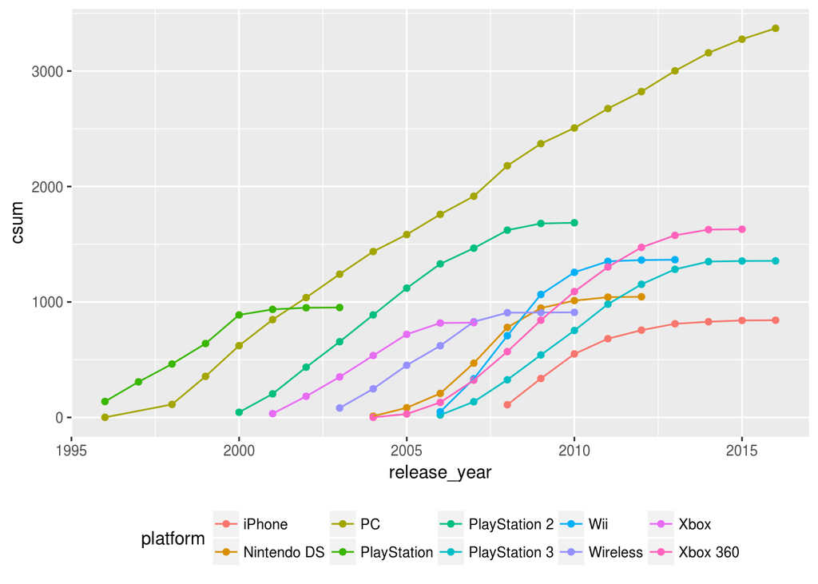

```r
df_plot = left_join(df_total,df,by ="platform") %>%
  group_by(platform,release_year) %>%
  summarise(count = n()) %>%
  group_by(platform) %>%
  arrange(release_year) %>%
  mutate(csum = cumsum(count))

ggplot(df_plot, aes(x=release_year, y = csum, colour = platform)) +
  geom_point() +
  geom_line() +
  theme(legend.position = "bottom")
```

- Logistic regression
- Support vector machine regression

### Logistic Regression

The dataframe will be split into training, testing. The data is split to 60:40 for training and testing.The reason for this choice of split is to better understand the underlying distribution and then test the results with the remaining 40% of the data.

```r
df_t <- df_p[complete.cases(df_p),]
df_t$editors_choice <- as.character(df_t$editors_choice)
train <-createDataPartition(y = 1:nrow(df_t),p = 0.6, list = FALSE)
training <- df_t[train,]
testing <- df_t[-train,]
```

The model is trained to test for the following formula `formula (editors_choice ~ platform + genre+ score_phrase + score)` using logistic regression.

```r
t1 <- confusionMatrix(predictions, testing$editors_choice)
print(t1)
```

```
## Confusion Matrix and Statistics
##
##           Reference
## Prediction    N    Y
##          N 5855  134
##          Y  212 1231
##
##                Accuracy : 0.9534
##                  95% CI : (0.9484, 0.9581)
##     No Information Rate : 0.8163
##     P-Value [Acc > NIR] : < 2.2e-16
##
##                   Kappa : 0.8481
##  Mcnemar's Test P-Value : 3.48e-05
##
##             Sensitivity : 0.9651
##             Specificity : 0.9018
##          Pos Pred Value : 0.9776
##          Neg Pred Value : 0.8531
##              Prevalence : 0.8163
##          Detection Rate : 0.7878
##    Detection Prevalence : 0.8058
##       Balanced Accuracy : 0.9334
##
##        'Positive' Class : N
##
```

### using Support vector machine

```r
t2 <- confusionMatrix(predictions2, testing$editors_choice)
print(t2)
```

```
## Confusion Matrix and Statistics
##
##           Reference
## Prediction    N    Y
##          N 5818  113
##          Y  249 1252
##
##                Accuracy : 0.9513
##                  95% CI : (0.9462, 0.9561)
##     No Information Rate : 0.8163
##     P-Value [Acc > NIR] : < 2.2e-16
##
##                   Kappa : 0.8436
##  Mcnemar's Test P-Value : 1.289e-12
##
##             Sensitivity : 0.9590
##             Specificity : 0.9172
##          Pos Pred Value : 0.9809
##          Neg Pred Value : 0.8341
##              Prevalence : 0.8163
##          Detection Rate : 0.7828
##    Detection Prevalence : 0.7980
##       Balanced Accuracy : 0.9381
##
##        'Positive' Class : N
##
```